# A sokasági átlag intervallumbecslése

Kovács László

2022. 08. 22.

## 1. Ismétlés: Az átlag standard hibája a Balaton átúszás eredményeken

Ugyebár a 3. heti tananyagban a 2022-es Balaton átúszás résztvevőinek időeredményeit vizsgáltuk mintavételi és becsléselméleti szempontból elég alaposan. Töltsük is be egy `pandas` data frame-be ismét a LIDLBalaton2022.xlsx fájl adatait. Ebben az Excelben megvan az összes résztvevő időeredménye a `PERC` oszlopban. Ez az adatsor lesz most nekünk tehát a **sokaságunk**.

```python
# Elemzéshez és ábrázoláshoz szükséges csomagok betöltése
import numpy as np
import pandas as pd
import matplotlib.pyplot as plt
import scipy.stats as stats

# Adatbeolvasás data frame-be
Balcsi = pd.read_excel("LIDLBalaton2022.xlsx")

Balcsi.info()
```

```
## <class 'pandas.core.frame.DataFrame'>
## RangeIndex: 9751 entries, 0 to 9750
## Data columns (total 3 columns):
##  #   Column  Non-Null Count  Dtype
## ---  ------  --------------  -----
##  0   Nev     9751 non-null   object
##  1   Nem     9751 non-null   object
##  2   PERC    9751 non-null   float64
## dtypes: float64(1), object(2)
## memory usage: 228.7+ KB
```

```python
Balcsi.head()
```

```
##                    Nev Nem        PERC
## 0           Aba Attila   F  142.416667
## 1        Abaffy Károly   F  197.883333
## 2        Abaffy Kornél   F  197.983333
## 3  Abelovszki Hajnalka   N  182.000000
## 4   Abért Valentin ifj   F  222.516667
```

Meg is van akkor mind az $N=9751$ részvevőnk. Ebben a tananyagban **most kizárólag az időeredmények átlagának becslésével** fogunk foglalkozni.  
Úgyhogy **számoljuk is ki**, hogy az összes átúszó, azaz a **sokaság**, tekintetében mi az **időeredmények átlaga** ($\mu=\bar{Y}$). Ezen kívül majd jól jön még nekünk referenciaként az időeredméynek sokasági **szórása** ($\sigma$) is.

```python
SokasagiAtlag = np.mean(Balcsi.PERC)
SokasagiSzoras = np.std(Balcsi.PERC)

SokasagiAtlag
```

```
## 167.52914060096398
```

```python
SokasagiSzoras
```

```
## 44.08833385551665
```

Tehát, **vegyünk is egy $n=100$ elemű mintát a Balatonátúszók sokaságából** a kedvenc $1992$-es véletlen magunk mellett, és nézzük meg, hogy **mennyi a mintaátlag, azaz $\bar{y}$ értéke**.

```python
BalcsiMinta = Balcsi.sample(n = 100, replace = True, random_state = 1992)

MintaAtlag = np.mean(BalcsiMinta.PERC)

MintaAtlag
```

```
## 164.44033333333334
```

Tehát ebben az $n=100$ elemű **mintában az átlagos átúszási idő $164.4$ perc**. A 3. heti tananyagban elvégzett okoskodásunk alapján a **mintaátlag alapján úgy tudjuk lehatárolni a sokasági átlag ($\mu$) értékét, hogy a mintaátlag értékre rámérem $\pm$ annak standard hibáját**. Hiszen a standard hiba megmutatja, hogy egy véletlenszerűen kiválasztott mintavétel átlaga várhatóan mennyivel tér el a valós sokasági átlagtól (mivel a $\bar{y}$ mintaátlag alapból egy torzítatéan becslőfüggvénye a $\mu$ sokasági átlagnak).  
A gondolatmenet alapján tehát azt mondhatjuk, hogy a **sokasági átlag várhatóan mintaátlag $\pm$ standard hiba által lehatárolt intervallumban nyugszik**.

Jó hír, hogy ugyebár az **átlag standard hibája sokasági szórás osztva gyök alatt mintaelemszám**, azaz $\frac{\sigma}{\sqrt{n}}$ képlettel számolható, aminek az értékét egy mintavétel alapján is meg tudjuk közelíteni, ha a sokasági szórást, annak torzítatlan becslésével a **korrigált mintaszórás**sal helyettesítjük. Tehát, az **egy szem $n=100$ mintából a standard hiba értéke az $\frac{s}{\sqrt{n}}$ képlettel megközelíthető**.

Ez alapján akkor az alábbi számolást tudjuk elkövetni a mintánkon.

```python
n = 100
s = np.std(BalcsiMinta.PERC, ddof = 1) # figyeljünk a korrekcióra!
SH = s/np.sqrt(n)

[MintaAtlag - SH, MintaAtlag + SH]
```

```
## [160.55804594814538, 168.3226207185213]
```

Az eredményünk alapján a valós, sokasági átlag ($\mu$) várhatóan $160.6$ és $168.3$ perc között, azaz a $[160.6,168.3]$ intervallumban helyezkedik el. Nos, **az intervallumos becslésünk helyes is, hiszen a valós sokasági átlag uygebár $\mu=167.5$ perc, ami tényleg benne van a mintánk alapján lehatárolt intervallumban**.

## 2. A mintaátlagok eloszlása

Na jó-jó, egy mintavétel esetén szerencsénk is lehetett. **Mennyire működik ez a standard hibás módszer jól sok-sok $n=100$ mintavétel esetében?** Töltsük csak be egy data frame-be azt a táblát, ami $10000$ db $n=100$ FAE mintavétel adatait tartalmazza! Az átlalam generált Excel, ami tartalmazza a $10000$ minta adatait [innen](https://github.com/KoLa992/Statisztika-II-Python-Jegyzet/blob/main/MintaDataFrame.xlsx) érhető el.

```python
MintaVetelek100Elem = pd.read_excel("MintaDataFrame.xlsx")
MintaVetelek100Elem
```

```
##            Elem1       Elem2       Elem3  ...      Elem98      Elem99     Elem100
## 0     164.800000  129.066667  156.166667  ...  207.350000  159.666667  165.883333
## 1     152.516667  212.483333  152.900000  ...  307.266667  119.783333  128.216667
## 2     145.666667  185.266667  169.516667  ...  167.733333  228.366667  215.633333
## 3     185.683333  120.333333  201.250000  ...  182.766667  177.666667  112.450000
## 4     117.483333  142.350000  320.266667  ...  188.566667  189.166667   99.916667
## ...          ...         ...         ...  ...         ...         ...         ...
## 9995  162.333333   83.350000  146.750000  ...  164.250000  131.933333  128.183333
## 9996  100.416667  161.433333  187.366667  ...  160.483333  168.416667  209.300000
## 9997  146.450000  160.783333  165.483333  ...  158.816667  167.733333  183.400000
## 9998  139.250000  140.466667  130.933333  ...  153.616667  112.366667  196.050000
## 9999  147.316667  173.450000  106.100000  ...  185.616667  171.800000  135.166667
##
## [10000 rows x 100 columns]
```

Oké, az eredményből látjuk is, hogy úgy néz ki a data frame, hogy **1 sor tartalmaz 1 db 100 elemű mintát és a mintaelemeket** (tehát a mintába besorsolt versenyző percben mért időeredményét) **az oszlopkban tároljuk**.

Akkor most **minden minta esetében számoljuk ki a $\bar{y} \pm SH$ intervallumot**, és nézzük meg, hogy a valós **sokasági átlag** ($\mu$) **beleesik-e** az intervallumba! Annyi **előnyt is adjunk magunknak, hogy a standard hibát a sokasági szórás, azaz $\sigma$ ismeretében számoljuk ki**. Tehát a $SH = \frac{\sigma}{\sqrt{n}}$ képletet alkalmazzuk. Ugye ez annyiban előny, hogy $\sigma$-t egy db 100 elemű minta vizsgálata esetén NEM ismerjük!  
A számolás során figyeljünk arra, hogy a `numpy` függvényeket `axis = 1` paraméterrel hazsnáljuk, hiszen egy db minta elemei a sorokban vannak. Illetve, a számolást mindig szorítsuk le a data frame első $100$ oszlopára, hiszen a data frame oszlopait folyamatosan bővíteni fogjuk!

```python
n = 100
SH = SokasagiSzoras / np.sqrt(n)

MintaVetelek100Elem['AtlagAlsoHatar'] = np.mean(MintaVetelek100Elem.iloc[:,0:100], axis = 1) - SH
MintaVetelek100Elem['AtlagFelsoHatar'] = np.mean(MintaVetelek100Elem.iloc[:,0:100], axis = 1) + SH
MintaVetelek100Elem
```

```
##            Elem1       Elem2  ...  AtlagAlsoHatar  AtlagFelsoHatar
## 0     164.800000  129.066667  ...      166.852833       175.670500
## 1     152.516667  212.483333  ...      153.617667       162.435333
## 2     145.666667  185.266667  ...      167.870000       176.687667
## 3     185.683333  120.333333  ...      159.025333       167.843000
## 4     117.483333  142.350000  ...      162.144000       170.961667
## ...          ...         ...  ...             ...              ...
## 9995  162.333333   83.350000  ...      159.273500       168.091167
## 9996  100.416667  161.433333  ...      159.924000       168.741667
## 9997  146.450000  160.783333  ...      159.293500       168.111167
## 9998  139.250000  140.466667  ...      162.015000       170.832667
## 9999  147.316667  173.450000  ...      168.641500       177.459167
##
## [10000 rows x 102 columns]
```

Oké, akkor **meg is vannak** az átlag intervallumos **becslés**ének **alsó-felső határai**. **Számoljuk** akkor **ki a találati arányt**!  
A számoláshoz azt a trükköt alkalmazzuk, amit a 2. heti tananyagban sütüttünk el: a `AdatokEgyben['Normal'] < 100` parancs egy `bool` tömböt ad vissza, amit összegezve megkapjuk a “*kedvező esetek*”, vagyis a $\mu$-t helyesen eltaláló intervallumok darabszámát.

```python
MintaVetelekSzama = len(MintaVetelek100Elem)

np.sum((MintaVetelek100Elem['AtlagAlsoHatar'] < SokasagiAtlag) & (MintaVetelek100Elem['AtlagFelsoHatar'] > SokasagiAtlag)) / MintaVetelekSzama
```

```
## 0.684
```

Nos, olybá tűnik, hogy a $\bar{y} \pm SH$ módszer csak a **mintavételek kb. $68\%$-ban találja el a valós, sokasági átalgot, azaz $\mu$-t!** Gáz Géza! Azért ennél nagyobb találati arányt szeretnénk! Mondjuk legalább valami $90\%$ környékét.

Ahhoz, hogy megértsük miért alakul gyéren ennek a módszernek találati aránya, **nézzünk csak rá az $\bar{y}$ mintaátlagok hisztogramjára!** Most a hisztogramon nem optimalizálom az osztályközök számát, elfogadom a `numpy` alapbeállításait.

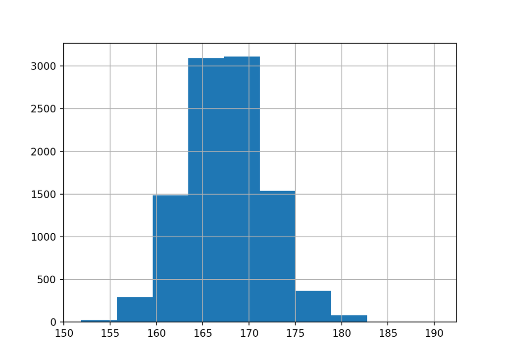

```python
MintaVetelek100Elem['MintaAtlagok'] = np.mean(MintaVetelek100Elem.iloc[:,0:100], axis=1)

MintaVetelek100Elem.MintaAtlagok.hist()
```

Hoppácska! Dehát, **ez itt a világ legszebb normális eloszlása!**

Ami azért második elgondolásra **teljesen logikus, mivel a Centrális Határeloszlás Tétel (CHT) dolgozik a háttérben**. Ha nem ugrik be a CHT, akkor vissza az 1. heti tananyag 2.4. fejezetéhez! :)

A **CHT** szerint ugyebár ha az **adatsor elemi véletlen hatások összegződéseként állnak elő**, akkor az **adatsor normális eloszlás**t követ. A $\bar{y}$ **mintaátlagok adatsora pedig pont olyan adatsor, ami a CHT feltételnek megfelel!** Hiszen a mintaátlag úgy jön ki, hogy a mintaelemeket összeadom és elosztom a minta elemszámával. **Mivel a mintavétel módja FAE, így biztos lehetek benne, hogy egy mintaelem, az egy véletlen húzás, egy véletlen hatás eredménye. Aztán meg ezeket adom össze**. Végén osztok $n$-bel, de az mindig ugyan annyi, így nem változtat a lényegen.

Ha pedig a **sok-sok mintából számolt átlagok adatsora normális eloszlású, akkor azt is tudom, hogy milyen átlagú és milyen szórású normális eloszlást követ!**

- A **torzítatlanság** miatt tudom, hogy a mintaátlagok átlaga a sokasági átlag, azaz $\mu$.
- Mintaátlagok szórása pedig ugye nem más, mint a **standard hiba**, tehát $\frac{\sigma}{\sqrt{n}}$

Szumma szummárom, akkor a **sok-sok mintából számolt mintaátlagok $\bar{y}$ adatsora az alábbi eloszlást követi**:
$$\bar{y} \sim N\left(\mu,\frac{\sigma}{\sqrt{n}}\right)$$

Ezt az illeszkedést simán letesztelhetjük grafikusan is az 1. heti tananyag 2.3. fejezetében látott módon.  
Figyeljük meg, hogy a `stats` csomag `norm.pdf` függvényében az átlagot a korábban kiszámolt `SokasagiAtlag`, a szórást pedig a szintén az előbb kiszámolt `SH` objektumok segítségével adom meg!

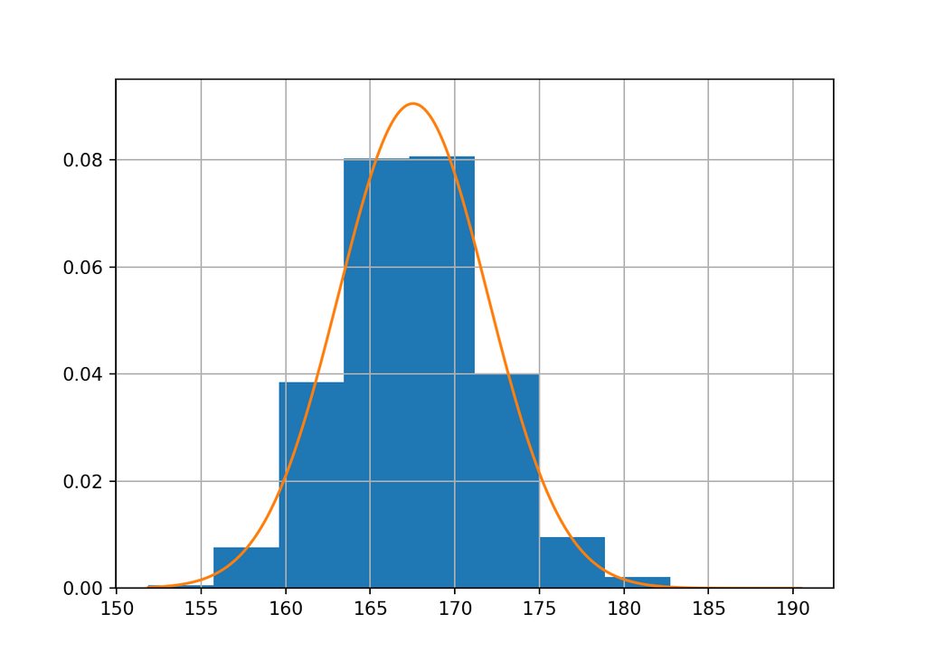

```python
MintaVetelek100Elem.MintaAtlagok.hist(density = True)
x_tengely = np.arange(np.min(MintaVetelek100Elem.MintaAtlagok), np.max(MintaVetelek100Elem.MintaAtlagok), 0.01)
y_tengely = stats.norm.pdf(x = x_tengely, loc = SokasagiAtlag, scale = SH)
plt.plot(x_tengely, y_tengely)
plt.show()
```

Nagyon szép, az illeszkedés, olybá tűnik a **CHT ismét működik**! :)

## 3. A sokasági átlag konfidencia-intervalluma

Nézzük akkor meg **mi a valószínűsége, hogy egy véletlenszerűen kiválasztott érték egy $N(\mu, SH)$ eloszlásban a $\mu \pm SH$ intervallumba esik!**

```python
stats.norm.cdf(x = SokasagiAtlag + SH, loc = SokasagiAtlag, scale = SH) - stats.norm.cdf(x = SokasagiAtlag - SH, loc = SokasagiAtlag, scale = SH)
```

```
## 0.682689492137087
```

Hoppáré! Ez is éppen kb. $68\%$! Tehát, **az, hogy egy $\bar{y} \pm SH$ becslés csak a mintavételek $68\%$-ban pontos nagyjából egy valószínűségszámítási szükségszerűség**.

Kérdés, hogy **mit tehetünk ez ellen? Mihez kezdhetünk, ha mondjuk nem $68\%$-os, hanem valami jobb, mondjuk $95\%$-os megbízhatóságú intervallumbecslést szeretnénk adni a sokasági átlagra (vagy más néven sokasági várható értékre)?**

Az okoskodáshoz az 1. heti tananyag 2.6. fejezetére fogunk támaszkodni.

Ugyanis azt tudjuk, hogy ha a **mintaátlagok eloszlása** az alábbi:
$$\bar{y} \sim N\left(\mu,\frac{\sigma}{\sqrt{n}}\right)$$

Akkor a **standardizált/normalizált mintaátlagok eloszlása pedig standard normális eloszlású lesz**:
$$\frac{\bar{y}-\mu}{\frac{\sigma}{\sqrt{n}}} = z \sim N(0,1)$$

Most az egyszerűség miatt vegyük a $\approx$-ot $=$-nek:
$$P(-2<z<+2) = 95\%$$

Ebbe a **fenti összefüggésbe beírjuk a képletet, amivel kiszámoltuk $z$-t**:
$$P\left(-2< \frac{\bar{y}-\mu}{\frac{\sigma}{\sqrt{n}}} <+2\right) = 95\%$$

Most egyelőre azzal a feltevéssel élünk, hogy ismerjük $\sigma$-t, azaz a sokasági szórást. Mondjuk pl. valami előzetes teljeskörű adatfelvételből. Célunk, hogy a valós, sokasági átlagot ($\mu$-t) foglaljuk valamiféle határok közé egy darab mintaátlag ($\bar{y}$) ismeretében (hiszen majd nem akarjuk mindig kivenni az összes lehetséges mintát). Tehát, az összefüggésből fejezzük a $\mu$ sokasági átlagot:
$$P\left(\bar{y}-2 \times \frac{\sigma}{\sqrt{n}}< \mu <+2 \times \frac{\sigma}{\sqrt{n}}\right) = 95\%$$

Tehát, ez a fenti összefüggés azt jelenti, hogy a **sokasági átlag az egy darab mintaátlag $\pm 2SH$ intervallumban van kb. $95\%$-os valószínűséggel**. Ezt hívjuk az **átlag 95%-os konfidencia-intervallumának**. A $2$ pedig a $95\%$-os megbízhatósági szinthez tartozó $k$ **megbízhatósági szorzó**. Mindezeket pedig csupán egy darab $n$ elemű mintából ki is tudjuk számolni, ha $\sigma$-t helyettesítjük $s$-sel! Viszont **fontos, hogy a mintánkat véletlenszerűen válasszuk ki, mert csak így kapunk a mintaátlagok eloszlására a látott normális eloszlást!** Ugyebár a CHT-nak kellenek a véletlen kiválasztású mintaelemek a “*véletlen hatások összegződése*” részhez.

### 3.1. Az átlag konfidencia-intervallumának általános alakja

Ha **átalánosságban akarjuk felírni ezt a konfidencia-intervallumot**, akkor úgy szoktunk fogalmazni, hogy $1-\alpha$ **megbízhatóságú intervallum**ot írunk fel, ahol $\alpha$ a **hibázásunk valószínűsége**, tehát, annak a valószínűsége hogy a sokasági átlag *mégsem* a konfidencia-intervallumban van:
$$P\left(\bar{y}-z_{1-\frac{\alpha}{2}} \times \frac{\sigma}{\sqrt{n}}< \mu <+z_{1-\frac{\alpha}{2}} \times \frac{\sigma}{\sqrt{n}}\right) = 1- \alpha$$

Itt a $z$ érték azt akarta jelenteni, hogy azt a $z$ **értéket kell levadászni, ami esetén az “alá esés” valószínűsége a standard normális eloszlásban épp** $1-\frac{\alpha}{2}$.  
Ennek okát szemlélteti az alábbi ábra.

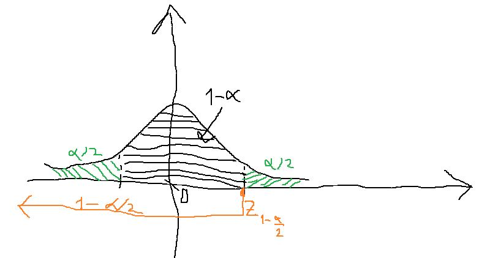

Ugyebár a cél az, hogy a $z \sim N(0,1)$ eloszlásban megtaláljuk azt a $k$ értéket, ahol $P(-k < z < +k)=1-\alpha$. Ugyebár a $95\%$ esetén is innen kaptuk a $2$-t. Ezt pedig akkor úgy kapjuk meg a **fenti ábra alapján**, hogy ha tudjuk, hogy a $\pm k$ közé esés valószínűsége $1- \alpha$, akkor a tartományon **kívülre esés valószínűsége** $\alpha$, a hibázásunk megengedett valószínűsége. Ami a normális eloszlás sűrűségfüggvényének **szimmetriája miatt egyenlően oszlik el** $-k$ alá és $+k$ felé. Tehát a $+k$ felé esési valószínűsége $\alpha / 2$. De mivel a pitonban a `stats` csomag `norm.ppf` függvénye **csak “alá esési” valószínűségekből dolgozik**, így a $+k$ alá esés valószínűséget kell tudnunk, ami a felé esés komplementere, azaz $1-\frac{\alpha}{2}$, ami az **ábrán a narancssárga rész területe a sűrűségfüggvényben**.

Láthatjuk a logika szuperül működik a $95\%$-os megíbzhatóság, azaz $\alpha=5\%$ esetére.

```python
alfa = 0.05

stats.norm.ppf(1-(alfa/2))
```

```
## 1.959963984540054
```

Az eredmény nem pontosan $2$, hanem kb. $1.96$. Ugyebár a **levezetésben kerekítettem**, de a megbízhatósági szorzó számítás lényege szerintem átjött. :)

**Szumma-szummárum**. Az **átlag tetszőleges megbízhatóságú intervallumbecslése / konfidencia-intervalluma általános alakban a következő módon számítható**:
$$\bar{y} \pm k \times SH$$

Tehát, a **mintaátlagra ($\bar{y}$) rámérjük $\pm$ a standard hiba $k$-szorosát, ahol a $k$, mint megbízhatósági szorzó állítja be a kívánt megbízhatósági szintet**.  
Ez az **általános formula azért nagyon fontos, mert a későbbiekben az átlagra vonatkozó becslések során mindig csak annyit változtatunk rajta, hogy az $SH$ és a $k$ mögött álló konkrét képlet fog csak változni, de ez a fenit alaplogika végig megmarad!!**

### 3.2. A konfidencia-intervallum megbízhatóságának ellenőrzése

Utolsó lépésben ellenőrizzük le konfidencia-intervallumos formulánk működését, és **nézzük meg, hogy a $\sigma$-val számolt $SH$-t használva** tudunk-e **egy $98\%$-os megbízhatóságú intervallumbecslés**t készíteni a Balatont átúszók időeredméyneinek átlagára a $k=z_{1-\frac{\alpha}{2}}$ megoldásunkkal.

Tehát a $10000$ db mintánk **mintaátlagára a mostani helyzetben** a
$$\triangle = k \times SH = z_{1-\frac{\alpha}{2}} \times \frac{\sigma}{\sqrt{n}}$$

távolságot kell $\pm$ felmérni. Ezt a $\triangle$ távolságot hívjuk a **konfidencia-intervallum hosszának, vagy másképp a becslés teljes hibahatárának**.

Nézzük akkor meg, hogy egy **ilyen becslés tényleg kb. $98\%$-os találati arányt eredményez-e?**

```python
n = 100
alfa = 1 - 0.98
k = stats.norm.ppf(1-alfa/2)
SH = SokasagiSzoras / np.sqrt(n)
delta = SH * k

MintaVetelek100Elem['AtlagAlsoHatar'] = MintaVetelek100Elem['MintaAtlagok'] - delta
MintaVetelek100Elem['AtlagFelsoHatar'] = MintaVetelek100Elem['MintaAtlagok'] + delta
MintaVetelek100Elem.iloc[:,99:103]
```

```
##          Elem100  AtlagAlsoHatar  AtlagFelsoHatar  MintaAtlagok
## 0     165.883333      161.005186       181.518147    171.261667
## 1     128.216667      147.770020       168.282980    158.026500
## 2     215.633333      162.022353       182.535314    172.278833
## 3     112.450000      153.177686       173.690647    163.434167
## 4      99.916667      156.296353       176.809314    166.552833
## ...          ...             ...              ...           ...
## 9995  128.183333      153.425853       173.938814    163.682333
## 9996  209.300000      154.076353       174.589314    164.332833
## 9997  183.400000      153.445853       173.958814    163.702333
## 9998  196.050000      156.167353       176.680314    166.423833
## 9999  135.166667      162.793853       183.306814    173.050333
##
## [10000 rows x 4 columns]
```

Oké, akkor **megvannak az új intervallumbecsléseink** mind a $10000$ mintára. Lássuk a pontosságukat!

```python
MintaVetelekSzama = len(MintaVetelek100Elem)

np.sum((MintaVetelek100Elem['AtlagAlsoHatar'] < SokasagiAtlag) & (MintaVetelek100Elem['AtlagFelsoHatar'] > SokasagiAtlag)) / MintaVetelekSzama
```

```
## 0.9782
```

És **tényleg kb. $98\%$ a találati arány**, győzelem! :)

### 3.3. A konfidencia-intervallum két fontos tulajdonsága

A konfidencia-intervallum **megbízhatósági szintjével csínján kell bánni**. Ha megfigyeljük a korábbi számításainkat, akkor láthatjuk, hogy

- $95\%$-os megbízhatósághoz $k=1.96$
- $98\%$-os megbízhatósághoz viszont már $k=2.3$

megbízhatósági szorzó tartozik.

A $\triangle = k \times SH$ összefüggés miatt pedig könnyű látni, hogy **megbízhatósági szint növelésével a becslési hibahatár nő, azaz a konfidencia-intervallum tágul**. Teljesen logikus: ha **nagyobb találati arányt akarok, akkor “növelni kell a hálót”, így nagyobb eséllyel akad fenn rajta a sokasági átlag**.  
$100\%$-os megbízhatóság pedig egy esetben van, ha az intervallumbecslésünk a $\pm \infty$ tartomány, ami ugyebár nem túl hazsnos becslési intervallum… :)

Érdemes kipróbálni a dolgot még az *1. fejezetben* kivett $100$ elemű mintán mondjuk $\alpha=\{0.2,0.1,0.05,0.01,0.001\}$ hibavalószínűségek mellett egy `for` ciklussal.  
A számoláshoz felhasználom a korábban kiszámolt `MintaAtlag` és `SH` objektumokat.

```python
alfa_lista = [0.2, 0.1, 0.05, 0.01, 0.001]

for aktualis_alfa in alfa_lista:
  also_hatar = MintaAtlag - SH * stats.norm.ppf(1-aktualis_alfa/2)
  felso_hatar = MintaAtlag + SH * stats.norm.ppf(1-aktualis_alfa/2)
  print(
    "Megbízhatóság: "+str((1-aktualis_alfa)*100)+"% - Konf. Int.: ["+
    str(round(also_hatar,2))+", "+str(round(felso_hatar,2))+"]")
```

```
## Megbízhatóság: 80.0% - Konf. Int.: [158.79, 170.09]
## Megbízhatóság: 90.0% - Konf. Int.: [157.19, 171.69]
## Megbízhatóság: 95.0% - Konf. Int.: [155.8, 173.08]
## Megbízhatóság: 99.0% - Konf. Int.: [153.08, 175.8]
## Megbízhatóság: 99.9% - Konf. Int.: [149.93, 178.95]
```

Szépen megfigyelhető a leírt jelenség: **a megbízhatóság növelésével a konfidencia-intervallum egyre csak tágul, azaz a becslési hibahatár folyamatosan nő**.

- $90\%$ megbízhatóság esetén az átlagos időeredményt még valahova $157$ és $172$ perc közé tippeljük,
- $99\%$ megbízhatóságnál viszont már $153$ és $176$ perc közé!

A jelenséget mérsékelni a **mintaelemszám növelésével lehet**! **Nézzük meg az előző `for` ciklust egy $n=20$ elemű mintán az $n=100$ helyett!** Számoljuk ki az első 20 oszlop alapján a $\bar{y}$ mintaátlagot. Mivel a kiválasztás FAE volt, így olyan lesz a dolog, mintha csak 20 elemet választottunk volna ki a mintavétel során, nem pedig 100-at. Az $SH=\frac{\sigma}{\sqrt{n}}$ is könnyen újraszámolható $n=20$ mellett.

```python
MintaAtlag20Elem = np.mean(BalcsiMinta.PERC[0:20])
n = 20
SH20Elem = SokasagiSzoras / np.sqrt(n)

alfa_lista = [0.2, 0.1, 0.05, 0.01, 0.001]

for aktualis_alfa in alfa_lista:
  also_hatar = MintaAtlag20Elem - SH20Elem * stats.norm.ppf(1-aktualis_alfa/2)
  felso_hatar = MintaAtlag20Elem + SH20Elem * stats.norm.ppf(1-aktualis_alfa/2)
  print(
    "Megbízhatóság: "+str((1-aktualis_alfa)*100)+"% - Konf. Int.: ["+
    str(round(also_hatar,2))+", "+str(round(felso_hatar,2))+"]")
```

```
## Megbízhatóság: 80.0% - Konf. Int.: [153.24, 178.5]
## Megbízhatóság: 90.0% - Konf. Int.: [149.66, 182.09]
## Megbízhatóság: 95.0% - Konf. Int.: [146.55, 185.19]
## Megbízhatóság: 99.0% - Konf. Int.: [140.48, 191.26]
## Megbízhatóság: 99.9% - Konf. Int.: [133.43, 198.31]
```

Szépen láthatjuk, hogy az **átlagos átúszási időket $99\%$-os megbízhatósággal**

- $n=20$ esetben $140$ és $191$ perc közé tesszük,
- $n=100$ esetben pedig láttuk az előbb, hogy a becslés pontosabb (kisebb $\triangle$ hibahatárú): $153$ és $176$ perc közé teszi a sokasági átlagidőt.

Nem meglepő az eredmény. Mivel a $\frac{\sigma}{\sqrt{n}}$ standard hiba **képlet nevezőjében van az $n$ elemszám, így növelése csökkenti a standard hibát, ezen keresztül pedig a teljes $\triangle$ becslési hibahatárt**. Ugyebár a 3. heti tananyagban megállapítottuk, hogy az átlag **konzisztens becslés**: elemszám növekedésével a $SH$-ja csökken, a $0$-ba tart.

Emiatt a **választott $1-\alpha$ megbízhatósági szint a mintaelemszám függvénye**:

- Nagyobb $n$ elemszám esetén egy $99\%$-os megbízhatóság is elég pontos intervallumbecslést szolgáltathat,
- Kisebb mintaméret esetén valószínűleg meg kell elégedni valami moderáltabb (pl. $90\%-95\%$) megbízhatósági szinttel is.

## 4. Intervallumbecslés a gyakorlatban

Ezen a ponton **engedjük el a Balaton átúszókat**, és **próbáljuk ki az átlag konfidencia intervallum számítást olyan esetben, ahol nem ismerjük a teljes sokaságot, amiből mintát vettünk**.

### 1. feladat: Altatók hatékonysága

A sztorink a következő.

Egy gyógyszergyár egy új altató készítmény hatását vizsgálja $10$ véletlenszerűen kiválasztott inszomniában szenvedő páciensen. Mind a tíz páciens esetében feljegyezték, hogy hány órát növekedett az alvásidejük a készítmény használatát követően. Korábbi klinikai vizsgálatok alapján ismeretes, hogy az altató készítmények által kiváltott alvásidő-változás normális eloszlású, $2$ óra szórással.

$Adatok = \{1.9, 0.8, 1.1, 0.1, -0.1, 4.4, 5.5, 1.6, 4.6, 3.4\}$

Készítsünk $95\%$-os megbízhatósággal intervallumbecslést a várható átlagos alvásidő-változásra:

1. a megadott feltételek alapján;
2. feltételezve, hogy az eloszlás normális, de a szórás ismeretlen!
3. Mekkora mintára van szükség, ha ugyan ekkora megbízhatóság (95%) mellett a b) pontban kapott hibahatárt a felére kívánjuk csökkenteni?

### 1/a) feladat megoldás

Ebben az a) feladatban nagyon el vagyunk kényeztetve. Az altató hatékonyságához van egy $n=10$ elemű mintánk, aminek az adatait tételesen ismerjük. Első páciens alvásideje $1.9$ órával nőtt az altató használata után, másodiké $0.8$ órával, stb. Van egy páciens, akinek csökkent az alvásideje a gyóygszerhasználat után: az 5. delikvensé, $0.1$ órával.  
Ha ezeket az adatokat elrakjuk egy `numpy` tömbbe, akkor simán kiszámolható a megfigyelt 10 páciens esetében az átlagos alvásidő növekedés, azaz $\bar{y}$

```python
MintaAdatok = np.array([1.9, 0.8, 1.1, 0.1, -0.1, 4.4, 5.5, 1.6, 4.6, 3.4])
MintaAtlag = np.mean(MintaAdatok)
MintaAtlag
```

```
## 2.3299999999999996
```

Tehát a megfigyelt páciensek esetében az átlagos alvásidő növekedés kb. $\bar{y}=2.3$ óra. Ami szép és jó, de mennyi lehet az **átlagos alvásidő növekedés az inszomniás páciensek összességére, a teljes sokaságra nézve? Ehhez kell a konfidencia-intervallum! Hogy olyan betegekre is tudjunk mondani valamit, akiket a mintában NEM figyeltünk meg!**

Itt az a) esetben minden **feltételezést elfogadhatunk, amit a feladat tesz**. Ebben van egy olyan rész, ami szerint “*korábbi kutatásokból*” ismerjük, hogy az alvásidő-változások szórása $2$. Ha ezt így elhisszük, akkor azt mondhatjuk, hogy az alvásidő-változások teljes sokaságra vonatkozó szórását vehetjük $2$-nek. Azaz, $\sigma=2$-t “*hazudunk*” a számolások során.  
**FIGYELEM!** Ha a feladat szövege azt akarja közölni velünk, hogy van egy sokasági szórás, egy $\sigma$, amit ismerünk és használhatunk a számolásaink során, akkor azt mindig ilyen “*korábbi kutatásokból ismeretes…*” szövegrészbe fogja becsomagolni!

Ha **elfogadjuk a feltételezéseinket, akkor minden adott a konfidencia-intervallum 3. fejezetben megismert képletének alkalmazásához**. Hiszen, ha $95\%$ a megbízhatóság, akkor $\alpha=5\%$. Tegyük is ezt: alkalmazzuk a képleteket az adatainkra!

```python
n = 10
alfa = 1-0.95
szigma = 2

k_szorzo = stats.norm.ppf(1-alfa/2)
SH = szigma/np.sqrt(n)
delta = k_szorzo*SH

also = MintaAtlag - delta
felso = MintaAtlag + delta

[also, felso]
```

```
## [1.0904099353908765, 3.5695900646091228]
```

Az eredmény alapján ez az **új alatató készítmény az inszomniás páciensek teljes sokaságában a 10 elemű mintánk alapján legalább $1.09$ óra és legfeljebb $3.6$ óra alvásidő növekedést okoz $95\%$-os valószínűséggel!**

Ennek a cég vezetése nagyon örül, mert lehet olyan reklámszlogeneket elsütni az eredményünk alapján, hogy “*vizsgálatok igazolják, hogy altatónk $95\%$-os valószínűséggel legalább $1$ órával növeli a várható alvásidőt*”. Egy ilyen mondat pedig minden marketinges álma *úgymond*. :)

De **minden ilyen szép marad-e ha az alvásidők szórását nem a feltételezett** $\sigma=2$-vel, hanem a **mintából számolt korrigált szórással ($s$) számítjuk?**

### 1/b) feladat megoldás

Itt a feladat azt mondja, hogy ne higyjünk mindenféle kétes “*korábbi kutatásnak*”, ne fogadjuk el az általuk megadott $\sigma$-t, hanem **számoljunk magunknak egy korrigált mintaszórást**, azaz $s$-t (a korrigált mintaszórás ad torzítatlan becsést a valós, sokasági $\sigma$-ra), és számoljuk végig azzal a stanadard hibát $SH=\frac{s}{\sqrt{n}}$ módon.

Viszont, ha **feloldjuk azt a feltevésünk, hogy ismerjük a sokasági szórást az $SH$ számoláshoz** , akkor a **mintaátlagok normális helyett egy $n-1$ szabadságfokú t-eloszlást követnek**.

A **t-eloszlás sűrűségfüggvénye az alábbi alakot ölti**. Az szabadságfokokat az angol *degrees of freedom* kifejezésből $df$-el jelöljük.

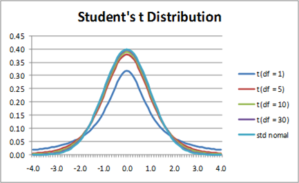

Ahogy a fenti sűrűségfüggvényből is létszik Student-féle t-eloszlás valójában egy **ellapított standard normális eloszlás** (lásd fenti ábra). A lapítás azt akarja kifejezni, hogy az eloszlás szórása nagyobb. Hiszen nagyobb szórás esetén az eloszlás szélein lévő számértékek is nagyobb valószínűséggel következhetnek be (mivel a lapítás miatt a sűrűségfüggvény magasabban fut ezeken a helyeken), így változatosabbá, jobban szóródóvá teszik az adatsorunk.

Viszont, ahogy növeljük az eloszlás szabadságfokát ($df$), egyre jobban “*visszacsúcsosítjuk*” az eloszlást a standard normális eloszlásba. Logikus, hogy ilyenkor ezt az eloszlást használjuk, mivel a standard hiba értékébe (ami a mintaátlagok normális eloszlásának szórás paramétere) egy biztosan ismert sokasági szórás érték helyett, annak egy mintából számított becslését rakjuk, így **nagyobb bizonytalanságot, nagyobb szórást viszünk az eloszlásba**.

Ebben a helyzetben a konfidencia-intervallum úgy módosul, hogy $\sigma$ helyére $s$ kerül a $SH$-ban, és a $k$ megbízhatósági szorzót $t$-eloszlásból számoljuk $N(0,1)$ eloszlás helyett:
$$P\left(\bar{y}-t_{1-\frac{\alpha}{2}}^{n-1} \times \frac{s}{\sqrt{n}}< \mu <+t_{1-\frac{\alpha}{2}}^{n-1} \times \frac{s}{\sqrt{n}}\right) = 1- \alpha$$

Az $n-1$ szabadságfokú $t$ érték számításához a `scipy` csomag `t.ppf` függvényét vesszük elő. Teljesen hasonló logikával működik, mint a `norm.ppf` függvény (vagy mint a `scipy` bármelyik eloszlás inverz értékét számoló függvénye). A $t$-eloszlás is szimmetrikus, tehát most is azt az értéket keressük az $n-1$ szabadságfokú $t$-eloszlásunkban, ahol az “*alá esési*” valószínűség $1-\frac{\alpha}{2}$. A `t.ppf` függvény `df` paraméterével állítható a szabadságfok.  
Ezt a mi $n=10$ elemű mintánkra, $95\%$-os megbízhatósági szint mellett az alábbi módon számoljuk

```python
n = 10
alfa = 1-0.95

k_szorzo_z = stats.norm.ppf(1-alfa/2)
k_szorzo_t = stats.t.ppf(1-alfa/2, df = (n-1))

[k_szorzo_z, k_szorzo_t]
```

```
## [1.959963984540054, 2.2621571627409915]
```

Láthatjuk, hogy **a $t$-eloszlású $k$ szorzó értéke érdemben nagyobb, mint a standard normális eloszlású $k$ szorzóé ugyan arra a megengedett hibavalószínűségre**! Mivel a $t$-eloszlás nagyobb valószínűséget tulajdonít az extrém magas+alacsony értékek bekövetkezésének, így ha ezt alkalmazzuk, akkor ugyan ahhoz a megbízhatósági szinthez egy magasabb $k$ megbízhatósági szorzót kapunk a $SH$-hoz!

Ezek után igazából csak annyi a feladatunk, hogy a teljes becslési hibahatárt kiszámítsuk $\triangle = t_{1-\frac{\alpha}{2}}^{n-1} \times \frac{s}{\sqrt{n}}\right)$ módon, és ezt rámérjük $\pm$ a mintaátlagra, $\bar{y}$-ra. Ez már mehet ugyan úgy, mint az a) feladatban.

```python
korr_szoras = np.std(MintaAdatok, ddof = 1)

k_szorzo_t = stats.t.ppf(1-alfa/2, df = (n-1))
SH = korr_szoras/np.sqrt(n)
delta = k_szorzo_t * SH

also = MintaAtlag - delta
felso = MintaAtlag + delta

[also, felso]
```

```
## [0.8976775394129308, 3.762322460587068]
```

Nem meglepő módon, a **t-eloszlású megbízhatósági szorzó miatt a $95\%$-os kinfidencia-intervallum kitágult**. Annak ellenére is, hogy az $SH$-ban gyakorlatilag nincs változás, mivel $s=2.0022$. Az altató átlagos alvásidő növekedése a betegek teljes sokaságban, már $0.9$ és $3.76$ óra közé tehető $95\%$-os valószínűséggel. Szóval, ebben a reálisabb helyzetben, amikor már a szórást magunknak számoljuk a mintaadatokból, és nem pedig “*elhisszük*” valakinek, akkor a bizonytalanság megnövekedése miatt alkalmazott t-eloszlásnak köszönhetően, a becslési hibahatár, a $\triangle$ kitágul. A marketingesek pedig már nem mondhatnak olyan szépeket, hogy “95%-os valószínűséggel legalább átlag $1$ órát növeli az alvásidőt az altató”. RIPSZ! :(

Viszont, amíg a **mintánk elemszámi kicsi**, $n \leq 30$, addig a **t-eloszlású konfidencia intervallum számításának van egy előfeltétele: az adatsor, amiből a mintát vesszük normális eloszlású kell, hogy legyen!!**  
Esetünkben ez annyit tesz, hogy az inszomniás páciensek sokaságában az *alvásidő normális eloszlású* hisztogramot mutat.

Na, most itt ezt kemény $n=10$ esetben marha nehéz értelmesen megvizsgálni a minta alapján, de lessünk egy hisztogramot a megfigyelt $10$ db alvásidőre! A hisztogram osztályközeinek számát most nem optimalizáljuk, elfogadjuk az alapbeállításokat.

```python
plt.hist(MintaAdatok)
```

```
## (array([2., 1., 1., 2., 0., 0., 1., 0., 2., 1.]), array([-0.1 ,  0.46,  1.02,  1.58,  2.14,  2.7 ,  3.26,  3.82,  4.38,
##         4.94,  5.5 ]), <BarContainer object of 10 artists>)
```

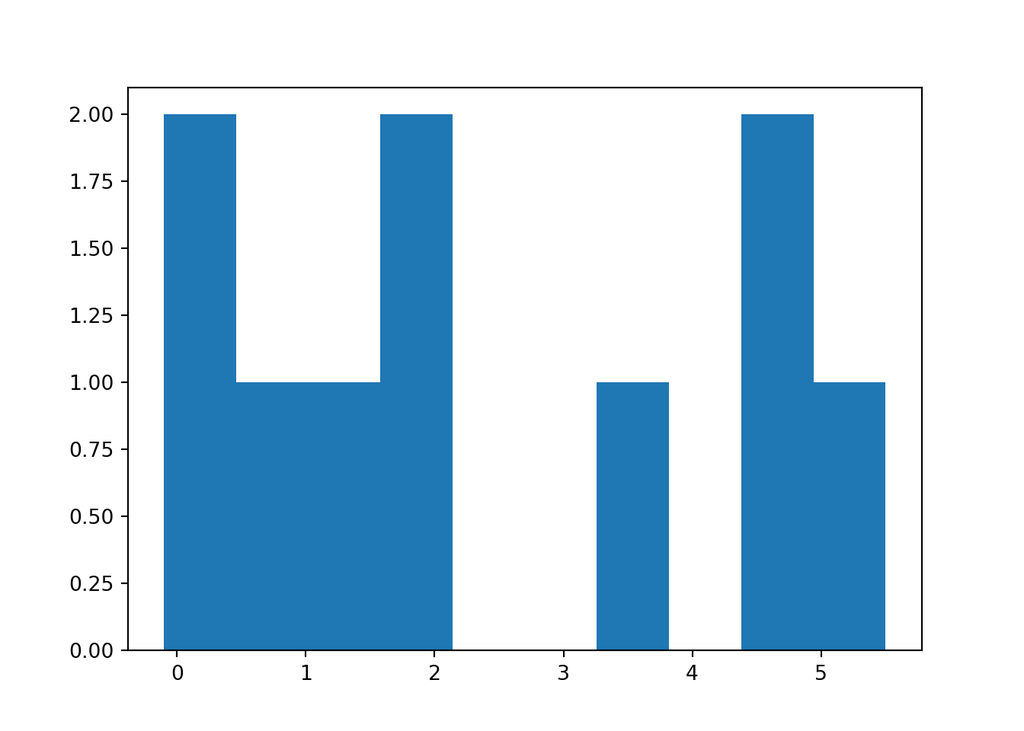

```python
plt.show()
```

Hát, a fene se tudja ennyiből eldönteni, de tényleg. Akár normális eloszlásúak lehetnek az alvásidők. :) Bízzunk a *CHT*-ben: az egyéni alvásidők valószínűleg véletlen hatások összegeként állnak elő, így azok adatsora a sokaságban, a nem megfigyelt $10$ elemű mintán *kívüli* világban, lehet normális eloszlású is akár. :)

Maga a *t-eloszlás* egyébként egy *William Gosset* nevű angol statisztikus kreatúrája. Mr. Gosset a *Guiness* sörgyárak minőségbitosítási vezetője volt, és azt a feladatot kapta, hogy oldja meg, hogy az üveges sörök minőségbiztosítása kis mintákból is megoldható legyen. Mivel a minőségbiztosításhoz ki kell bontani az üveget és megmérni benne az összetevőket, aztán utána ezek átlagára néznek konfidencia-intervallumokat. A minőségbiztosításra kinyitott sör pedig már nem elfogyasztható. *Kellemetlen*.  
Így érhető, hogy minél kevesebb üvegből akarják az egész minőségbiztit megúszni. Erre adta megoldásként Gosset a t-eloszlást. Mivel a sörökben a különböző alapanyagok értéke normális eloszlást követ.

Azonban emberünk el akart büszkélkedni a saját kis elszlásával a nagy világban, ezért *Student álnéven* publikálta is az eredményeit…innen lett az eloszlás neve *Student-féle t-eloszlás*. :) Viszont nagyon nem volt előrelátó az úriemberünk, hiszen akkoriban nyilván csak a Guiness sörgyár tudott elég kevés üvegből ugyan olyan “jó” megbízhatósággal minőségbiztosítani, mintha több elemű mintát vizsgáltak volna, így *Mr. Gosset* gyorsan lebukott.

Tehát, ahogy az alábbi ábra is mutatja, szegény emberünk csak a sörtermelést szerette volna hatékonyabbá tenni, de végül mindenki életét tönkretette, aki statisztikai becsléselméletet tanul. :)

[figure not shown]

### 1/c) feladat megoldás

Node, térjünk vissza az altató készítményünk hatékonyságára. Ugyebár a t-eloszlással készített konfidencia-intervallum eléggé elkeserítő eredményt hozott: nem tudjuk azt mondani $95\%$-os megbízhatósággal, hogy készítményünk legalább $1$ órával növeli az alvásidőt!

Mi ennek az oka? Hát a **magas becslési hiba, az átlagra épített konfidencia-intervallum hossza**, tehát a $\triangle$. Ez most ugye nekünk $\pm 1.43$ óra.

```python
delta
```

```
## 1.4323224605870688
```

Mondjuk ezt a becslési **hibahatárt szeretnénk levinni a felére**, $1.43/2$, azaz kb. $\triangle'= \pm 0.7$ órára. Ezt kétféleképpen lehet elérni. Hiszen “*magasról nézve*”, a becslési hibahatár egy kéttényezős szorzat
$$\triangle=k \times SH$$

1. Addig állítgatom a megbízhatósági-szintet, azaz valójában $\alpha$-t, amíg a t-eloszlásból származó $k$ megbízhatósági szorzó olyan alacsony nem lesz, hogy az eddigi $SH$-val szorozgatva ki nem adja a $0.7$-es értéket $\triangle$-re. Ez az **illetlen megoldás**! Hiszen lehet, hogy ehhez az $\alpha$-t nagyon fel kell engedni, és a becslésnek nagyon alacsony lesz a megbízhatósága…az “$55\%$-os megbízhatósággal állítható az, hogy…” nem hangzik olyan jól marketing szempontból sem.
2. Az **intelligens megoldás** a mintaelemszám, azaz $n$ növelése. Az $\alpha$-t adottnak vesszük, és így $k$-t nem bántjuk. Persze a t-eloszlás szabadságfoka miatt az elemszám $k$-ra is hat, de ahogy az eloszlás sűrűségfüggvényéből is látszik, kellően nagy $n$ esetén a t-eloszlás igazából a standard normálissal lesz ekvivalens, tovább tehát nem tudjuk csökkenteni $k$-t adott $\alpha$ mellett. Tehát ekkor a $k$ lényegében fix. Ellenben $n$ növekedése miatt az $SH$ része a szorzatnak biztosan csökkeni fog, hiszen az átlagra konzisztens becslést adunk, tehát $SH$ a $0$-ba tart $n$ növelése esetén. Ez ugye a $SH=\frac{s}{\sqrt{n}}$ összefüggésből adódik egyértelműen. Szóval az $s$-t (vagy éppen $\sigma$-t, ha azt ismerjük) adottnak vesszük, akkor kiszámolhatjuk, hogy mekkora $n$ szükséges a $\triangle'= \pm 0.7$ óra eléréséhez hibahatár fronton.

Szóval, a 2. megoldást, az elemszám növelését választva a következő összefüggésből ki kell fejezni $n$-t:
$$\triangle=k \times SH = z_{1-\frac{\alpha}{2}} \times \frac{s}{\sqrt{n}}$$

Hiszen $\triangle$ helyére beírhatjuk nemes egyszerűséggel az elérni kívánt $\triangle$-t. A $k$ helyére azért írtam $z_{1-\frac{\alpha}{2}}$-t és nem a t-eloszlású szprzót, mert a standard normális eloszlású megbízhatóságú szorzó értéke alá úgysem tudunk menni a t-eloszlással adott $\alpha$ mellett, hiszen a t-elsozlású sűrűségfüggvényt végtelen szabadságfok mellett is csak a standard normális eloszlásba lehet maximum “*visszacsúcsosítani*”, ahogy a b) feladat megoldásában szereplő ábrán láthattuk is.

Ha pedig a fent formulából kifejeztük az elemszámot, akkor ehhez az összefüggéshez jutunk:
$$n=\frac{z_{1-\frac{\alpha}{2}}^2 \times s^2}{\triangle^2}$$

Ebbe pedig gond nélkül be tudunk helyettesíteni mindent.

```python
delta_uj = 0.7

n_uj = k_szorzo_z**2 * korr_szoras**2 / delta_uj**2
n_uj
```

```
## 31.429404922781128
```

Tehát a becslési ha felezéséhez $n=31.4$ elemű minta kéne… mivel egyik betegből sem vágnánk ki $0.4$ részt a vizsgálatra, így logikus módon az eredményt kerekítsük fel $n=32$-re. **Azaz, $32-10=22$ páciensen kéne még extrában megvizsgálni az altató hatását ahhoz, hogy az átlagos alvásidő növekedést $95\%$-os megbízhatósággal és $\pm0.7$ órás becslési hibával meg lehessen adni**.  
Persze, ha a mintaátlag vagy éppen a korrigált mintaszórás úgy módosul az új mintaelemek hatására, hogy a konfidencia-intervallum alsó határa továbbra sem éri el a vágyott $1$ órát, akkor tervünk dugába dőlt. Viszont, akkor ez inkább a gyógyszert fejlesztő vegyészek sara, mint a hatékonyságvizsgálatot végző statisztikusé, aki rávilágít a problémákra. :)

### 2. feladat

Az ESS2020.xlsx fájlban található adatbázis a 2020-ban végzett európai szociális felmérés (European Social Survey 2020 = ESS2020) 1849 magyar kitöltöjének válaszait tartalmazza 14 kérdésre (plusz van egy *id* oszlop).

Ha valamelyik oszlopban üres értéket találunk, akkor az adott sorban lévő kitöltő nem válaszolt a kérdésre. Az adatbázisban szereplő kitöltők a teljes 18 év feletti magyar népességből vett véletlen mintaként kezelhetők. Most feltesszük, hogy ez a véletlen minta visszatevéses, azaz $FAE$ is. A 6. heti tananyagban látni fogjuk, hogy ez nem is valóságtól elrugaszkodott feltevés.

Az adatbázis nyers formában [eről a linkről](https://ess-search.nsd.no/en/study/172ac431-2a06-41df-9dab-c1fd8f3877e7) elérhető egy ingyenes regisztráció után.

**Feladatunk** a mintavétel alapján megbecsülni, hogy hogy egy átlagos magyar polgár $97\%$-os megbízhatósággal várhatóan legalább és legfeljebb hány percet internetezik naponta!

### 2. feladat megoldás

Először is töltsök be az adatbázist `pandas` data frame-be és nézzük meg az elemszámot a feladat szempontjából releváns `NetUsePerDay_Minutes` oszlopban!

```python
ESS = pd.read_excel("ESS2020.xlsx")
ESS.info()
```

```
## <class 'pandas.core.frame.DataFrame'>
## RangeIndex: 1849 entries, 0 to 1848
## Data columns (total 15 columns):
##  #   Column                          Non-Null Count  Dtype
## ---  ------                          --------------  -----
##  0   id                              1849 non-null   int64
##  1   PoliticalRadioTVPerDay_Minutes  1796 non-null   float64
##  2   NetUsePerDay_Minutes            1099 non-null   float64
##  3   TrustInParlament                1849 non-null   object
##  4   PoliticalPartyPref              1849 non-null   object
##  5   Education_Years                 1830 non-null   float64
##  6   WeeklyWork_Hours                685 non-null    float64
##  7   Region                          1849 non-null   object
##  8   County                          1849 non-null   object
##  9   SecretGroupInfluenceWorldPol    1849 non-null   object
##  10  ScientistsDecievePublic         1849 non-null   object
##  11  COVID19                         1849 non-null   object
##  12  ContactCOVID19                  1849 non-null   object
##  13  GetVaccince                     1849 non-null   object
##  14  SomeContactCOVID19              1849 non-null   object
## dtypes: float64(4), int64(1), object(10)
## memory usage: 216.8+ KB
```

```python
n = ESS.NetUsePerDay_Minutes.count() # így nem számoljuk be az üres értékeket
n
```

```
## 1099
```

Szóval, az üres értékeket nem számolva, a releváns oszlop `count` metódusával megtudhattuk, hogy az internetezési idő esetében $n=1099$ elemű mintából főzhetünk. **Ez bőven nagy minta**, mivel ebből a tárgyból közmegegyezéssel **az $n > 30$ eseteket nagy mintának tekintjük**, ahogy az 1/b) feladat megoldásában megadtuk. Emiatt **nem kell az intrenetezési idők normális eloszlását sem vizsgálni az intervallumbecslés elvégzéséhez $s$-t és t-eloszlást használva**!

Mehetünk simán előre a $\triangle = t_{1-\frac{\alpha}{2}}^{n-1} \times \frac{s}{\sqrt{n}}\right)$ képletet használva.

```python
n = ESS.NetUsePerDay_Minutes.count() # így nem számoljuk be az üres értékeket

minta_atlag = np.mean(ESS.NetUsePerDay_Minutes)
korr_szoras = np.std(ESS.NetUsePerDay_Minutes, ddof = 1)

SH = korr_szoras / np.sqrt(n)

alfa = 1-0.97
k_szorzo_t = stats.t.ppf(1-alfa/2, df = (n-1))

delta = k_szorzo_t * SH

also = minta_atlag - delta
felso = minta_atlag + delta

[also, felso]
```

```
## [171.77362310362494, 190.8141839937363]
```

Tehát, az $n=1099$ elemű mintánk alapján azt mondhatjuk, hogy az átlagos magyar $97\%$-os megbízhatósággal legalább napi $171.8$ percet és legfeljebb napi $190.8$ percet tölt internetezéssel.

Az eredményünk nem nagyon változik, ha a $k$ megbízhatósági szorzót standard normális eloszlásból számoljuk t-eloszlás helyett, hiszen az $n$ olyan nagy, hogy az $n-1$ szbadságfokú t-eloszlás sűrűségfüggvénye lényegében semmiben nem fog különbözni a standard normális eloszlás sűrűségfüggvényétől.

```python
alfa = 1-0.97
k_szorzo_z = stats.norm.ppf(1-alfa/2)

delta = k_szorzo_z * SH

also = minta_atlag - delta
felso = minta_atlag + delta

[also, felso]
```

```
## [171.78599827499198, 190.80180882236925]
```

Láthatjuk, hogy csak a tizedesjegyekben vannak nagyon minimális eltérések. Szóval **nagy mintaelemszám esetén a megbízhatósági szorzó nyugodtan számolható standard normális eloszlásból is a t-eloszlás helyett**.

Szerencsénkre, a `scipy` csomagban az átlag konfidencia-intervallumának számítására standard normális és t-eloszlású $k$ szorzók esetében is **vannak beépített függvények**.  
Ezek értelemszerűen `stats.norm.interval` és `stats.t.interval` nevekre hallgatnak.

Először nézzük meg, hogy tényleg használható a `stats.sem` függvény $SH$ szmításra. A `nan_policy = 'omit'` paraméterbeállítással szólunk neki, hogy a hiányzó értékeket ne vegye figyelembe a számítás során, ahogy mi is tettük.

```python
SH_Adatokbol = stats.sem(ESS.NetUsePerDay_Minutes, nan_policy = 'omit')

[SH_Adatokbol, SH]
```

```
## [4.381340690645104, 4.381340690645104]
```

Egyezük, szuper! :)

Most pedig szépen használhatjuk a kétféle eloszlássa dolgozó konfidencia-intervallum számító függvényt is.

```python
stats.norm.interval(
  alpha=0.97,
  loc=np.mean(ESS.NetUsePerDay_Minutes),
  scale=stats.sem(ESS.NetUsePerDay_Minutes, nan_policy = 'omit'))
```

```
## (171.78599827499198, 190.80180882236925)
##
```

```python
stats.t.interval(
  alpha=0.97,
  loc=np.mean(ESS.NetUsePerDay_Minutes),
  scale=stats.sem(ESS.NetUsePerDay_Minutes, nan_policy = 'omit'),
  df = (ESS.NetUsePerDay_Minutes.count() - 1))
```

```
## (171.77362310362494, 190.8141839937363)
```

Egyezünk a korábbi eredményeinkkel, szuperek vagyunk! :)

## 5. Összefoglalás az átlag konfidencia-intervallumairól

Ezen a ponton érdemes összefoglalni, hogy az átlag intervallumbecslése milyen feltételek mellett milyen konkrét formulák vannak.

Az **alapképlet a konfidencia-intervallum hosszára, azaz a becslési hibahatárra**:
$$\triangle = k \times SH$$

1. A sokasági szórás, alias $\sigma$ ismert.
- $k=z_{1-\frac{\alpha}{2}}$
- $SH=\frac{\sigma}{\sqrt{n}}$
2. Az adatsor, amiből a mintát vettük *normális eloszlás*ú
- $k=t_{1-\frac{\alpha}{2}}^{n-1}$
- $SH=\frac{s}{\sqrt{n}}$
3. A mintánk elemszáma nagy: $n > 30$
- $k=t_{1-\frac{\alpha}{2}}^{n-1}$ vagy $k=z_{1-\frac{\alpha}{2}}$
- $SH=\frac{s}{\sqrt{n}}$

És ennyi, igazából, ha végiggondoljuk a 4. fejezet feladatait, ezt a $3$ esetet tudjuk elkülöníteni a $\triangle$ számítása során.

## 6. Esettanulmány

Vizsgáljuk meg $99\%$-os megbízhatósággal hogyan alakul az átlagos internetezéssel töltött idő a teljes magyar népességben pártpreferencia szerint!

Érdekes megnézni, hogy egy $n=1099$ elemű mintában mért átlagos különbségek az egyes pártok intenetezési idejében mennyire általánosíthatók ki a pártokat támogató népesség egészére, tehát azokra az emberekre, akiket a mintában még NEM figyeltünk meg, azaz a **mintaelemeken kívüli világra**.

Ehhez az út ott kezdődik, hogy a nominális ismérvünk, azaz a pártpreferemcia egyedi értékei szerint vesszük az átlaggal vizsgált mennyiségi ismérv részátlagait, és ezen részátlagok $SH^2$-eit, azaz *becslési varianciáit*. Ezt a kiinduló data frame `groupby` metódusával gyorsan meg tudjuk oldani.

```python
# Először megtisztítjuk a 'NetUsePerDay_Minutes' oszlop üres értékeitől a data frame-t
df_szurt = ESS.loc[ESS.NetUsePerDay_Minutes.notna(),:]

PartPrefKimutatas = df_szurt.groupby("PoliticalPartyPref").agg(
  Elemszam = ('NetUsePerDay_Minutes', 'count'),
  Atlag = ("NetUsePerDay_Minutes", np.mean),
  SH = ("NetUsePerDay_Minutes", stats.sem)
)
# SH négyzetre emelés
PartPrefKimutatas['BecslesiVar'] = PartPrefKimutatas['SH']**2

PartPrefKimutatas
```

```
##                     Elemszam       Atlag         SH  BecslesiVar
## PoliticalPartyPref
## Egyesült Ellenzék        182  228.791209  12.500299   156.257485
## Egyéb                     13  129.230769  20.489570   419.822485
## Fidesz-KDNP              215  158.711628   8.225458    67.658164
## Nem Ismert               689  176.776488   5.486396    30.100541
```

Ezek után telepítsünk egy `statsmodels` néven futó csomagot!

```python
pip install statsmodels
```

Majd importákjuk a csomag `combine_effects` függvényét. Ha ennek a függvénynek az `effect` paraméterében megadjuk a mért mintaátlagokat, a `variance` paraméterben az $SH^2$-ket, `row_names` paraméternél a nominális kategóriáink neveit (most a pártpreferenciák lehetséges egyedi értékeit) és az `alpha` paraméterben megadjuk az $\alpha$-t (itt tényleg a megengedett *hibavalószínűséget* hívja a gépállat `alpha`-nak, ahogy kell), akkor a függvény kiszámolja **minden nominális csoportra**, azaz esetünkben pártpreferenciára, a **vizsgált részátlagok $1-\alpha$ megbízhatóságú konfidencia-intervallumát**.  
Annyi szépséghibája van csak a függvénynek, hogy mindezt **nagy mintát feltételezve teszi, tehát a $k$ megbízhatósági szorzót mindig standard normális eloszlásból számolja**. Szóval kis mintáknál ($n \leq 30$) a függvény a valós konfidencia-intervallumot *alulbecsli, azaz az eredmény túl szűk lesz*!  
Ez most nekünk **csak az $n=13$ elemszámú ‘Egyéb’ pártpreferencia csoportban lehet problémás**!

Az eredménytáblát a `summary_frame` metódussal tudjuk levadászni. Az eredményül kapott táblában az utolsó két oszloppal és utolsó négy sorral nekünk nem kell foglalkozni, így csak az első négy oszlopot és az első négy sort választjuk csak ki a megjelenítéskor. A soroknál azért csak az első négyet, mert *négy egyedi pártpreferencia értékünk van* itt és most! Egyébként a nominális ismérvünk egyedi értékeinek számához igazítjuk mindig a kiválasztást! . A `ci_low` és `ci_upp` oszlopok rendre a konfidencia intervallumunk alsó-felső határai.

```python
from statsmodels.stats.meta_analysis import combine_effects

eredmeny = combine_effects(
  effect = PartPrefKimutatas.Atlag,
  variance = PartPrefKimutatas.BecslesiVar,
  row_names = PartPrefKimutatas.index,
  alpha = (1-0.99)
)
eredmeny_tabla = eredmeny.summary_frame().iloc[0:4,0:4]
eredmeny_tabla
```

```
##                           eff     sd_eff      ci_low      ci_upp
## Egyesült Ellenzék  228.791209  12.500299  204.291072  253.291345
## Egyéb              129.230769  20.489570   89.071950  169.389589
## Fidesz-KDNP        158.711628   8.225458  142.590026  174.833230
## Nem Ismert         176.776488   5.486396  166.023349  187.529626
```

Remek! :) Az `eff` oszlop tartalmazza a mintaátlagokat, míg a `sd_eff` oszlop a $SH$-k lakóhelye. Tehát, ezek alapján azt mondhatjuk, hogy az egyesült ellenzék esetén egy átlagos kérdőívkitöltő $228.8$ percet netezik naponta, míg egy átlag Fidesz kitöltő csak napi $158.7$ percet.  
Azonban, a teljes ellenzéki népességben az átlag netezési idő $204$ és $253$ perc között van $99\%$-os valószínűséggel. A teljes fideszes táborban pedig az átlagos neten töltött idő csak $143$ és $175$ perc között mozog, szintén $99\%$-os valószínűséggel.  
Tehát, $99\%$-os valószínűséggel az átlag netezési idő az Ellenzék esetében magasabb, mint a Fidesz esetében a teljes népességben is, hiszen a “legrosszabb” ellenzéki átlagérték is már $204$ perc, míg a Fidesz esetén a “legjobb” átlagidő is csak $175$ perc.  
Mindez persze a különböző felületeken (tv, rádió, internet) működő médiumok irányultságát figyelembe véve egyáltalán nem meglepő. :)

A `statsmodels` csomag szépsége, hogy van egy `dot_plot` című függvénye, amivel csudiszép vizuális megjelenítés adható a csoportátlagoknak és a konfidencia-intervallumaiknak. Ezeket az ábrákat **forest diagram**oknak hívják.

A `dot_plot` függvény `points` paraméterébe kerülnek a mintaátlagok, míg az `intervals` paraméterbe egy olyan $2$ oszlopos data frame kerül, ami tartalmazza a konfidencia-intervallum alsó és felső határának távolságát a mintaátlagoktól abszolút értékben, azaz lényegében a $\triangle$-t. Igen, itt egy olyan data frame kell neki, ahol mindkét oszlopban ugyan az az érték szerepel, mert ezt méri rá majd a gépállat a `points` paraméterre $\pm$.  
Ahhoz, hogy szépen megjelenjenek a pártpreferenciák is, a függvénynek a `lines` paraméteren meg kell kapnia az eredménytábla soreindexeit is, hiszen a pártpreferencia értékek ott kerültek eltárolásra.

```python
from statsmodels.graphics.dotplots import dot_plot

# konfidencia-intervallumok méretének megadása az ábrához
intervallumok = np.abs(eredmeny_tabla[["ci_low", "ci_upp"]] - eredmeny_tabla[["eff"]].values)
intervallumok
```

```
##                       ci_low     ci_upp
## Egyesült Ellenzék  24.500137  24.500137
## Egyéb              40.158820  40.158820
## Fidesz-KDNP        16.121602  16.121602
## Nem Ismert         10.753139  10.753139
```

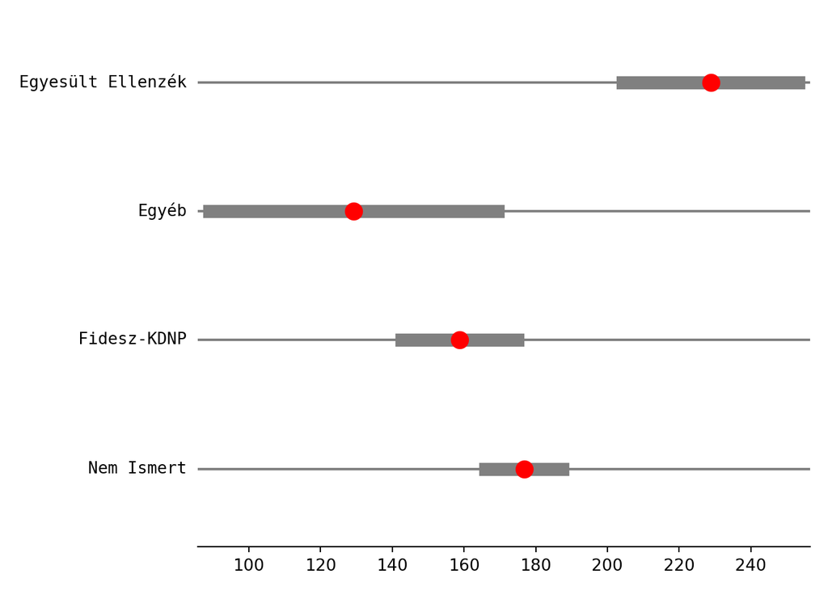

```python
dot_plot(
  points=eredmeny_tabla["eff"],
  intervals = intervallumok,
  lines=eredmeny_tabla.index)

plt.tight_layout() # ne csússzanak ki a tengelyfeliratok
plt.show()
```

Mint láthatjuk, igazából az Ellenzék átlagos netezési ideje az, ami konfidencia-intervallumokkal együtt is magasabb, mint a többi párt szavazóinak átlagos netezési ideje a teljes népességben. Sőt, a **többi párt esetében azt mondhatjuk, hogy egyáltalán nem biztos, hogy a teljes népességben ezek az átlag netezési idők különböznek** $99\%$-os megbízhatósággal, **mivel a konfidencia-intervallumok metszik egymást**. Szóval, hiába van a megfigyelt adatok körében a Fidesznek magasabb átlag netideje, mint az Egyéb pártoknak, de kevesebb, mint a Nem ismert eseteknek, a nem megfigyelt, mintán kívüli adatok körében, azaz a teljes népességben simán lehet ($99\%$-os megbízhatósággal), hogy a Fideszes szavazók neteznek átlag a legkevesebbet egy napon. Ehhez csak annyi kell, hogy az a Fidesz valós, sokasági átlaga a konfidencia-intervallum alsó határa körül legyen a teljes népességben, míg a többi párt (nem ismert és egyéb) átlagideje pedig a konfidencia-intervallumuk tetejénél “kössön ki” a teljes népesség körében.

Érdemes még megfigyelni, hogy az Egyéb pártoknak a legszélesebb a konfidencia-intervalluma. Ez ugye azért van, mert mint láttuk a fejezet elején ide csak $n=13$ kitöltő tartozik. Így az $SH=\frac{s}{\sqrt{n}}$ összefüggés miatt érthető, hogy nagyon bizonytalanok vagyunk ennél a csoportnál az átlagos netezési idő becslésében. Ráadásul ez egy durva alábecslés is, amit itt a konfidencia-intervallum hosszára látunk! Hiszen a kis elemszám miatt a $k$ megbízhatósági szorzót itt $13-1$ szabadságfokú t-eloszlásból kellene számítani standard normális helyett, ahogy a `combine_effects` függvény csinálja. Persze, ez sem lenne teljesen pontos, mivel ahogy az alábbi hisztogram is szemlélteti, a napi netezési idők nem normális, hanem jobbra elnyúló eloszlásúak.

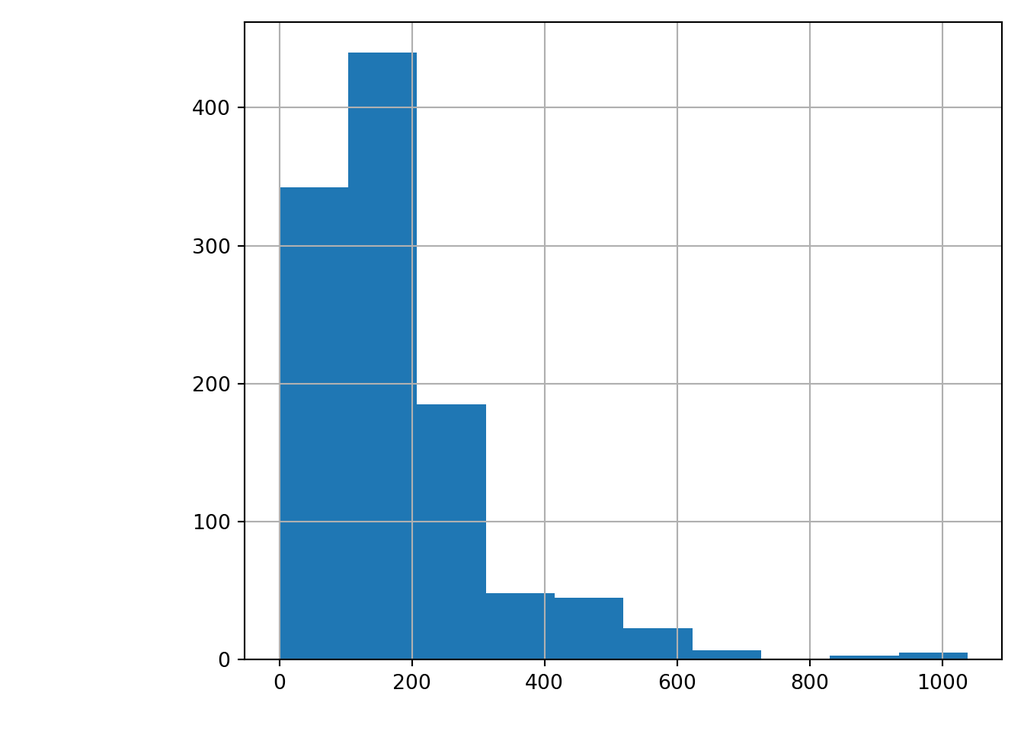

```python
ESS.NetUsePerDay_Minutes.hist()
plt.show()
```

Ha valaki szeretné végigszámolni és ábrázolni a konfidencia-intervallumokat t-eloszlással, megteheti. Ezt viszont “manuálisan” kell megcsinálni a `groupby`-al létrehozott data frame oszlopok bővítésén keresztül.

```python
alfa = 1-0.99

PartPrefKimutatas['ci_low_t'] = PartPrefKimutatas['Atlag'] - PartPrefKimutatas['SH'] * stats.t.ppf(1-alfa/2, df = (PartPrefKimutatas['Elemszam']-1))
PartPrefKimutatas['ci_upp_t'] = PartPrefKimutatas['Atlag'] + PartPrefKimutatas['SH'] * stats.t.ppf(1-alfa/2, df = (PartPrefKimutatas['Elemszam']-1))

PartPrefKimutatas
```

```
##                     Elemszam       Atlag  ...    ci_low_t    ci_upp_t
## PoliticalPartyPref                        ...
## Egyesült Ellenzék        182  228.791209  ...  196.249626  261.332792
## Egyéb                     13  129.230769  ...   66.644566  191.816972
## Fidesz-KDNP              215  158.711628  ...  137.333678  180.089577
## Nem Ismert               689  176.776488  ...  162.605159  190.947816
##
## [4 rows x 6 columns]
```

És végül a *forest diagram*.

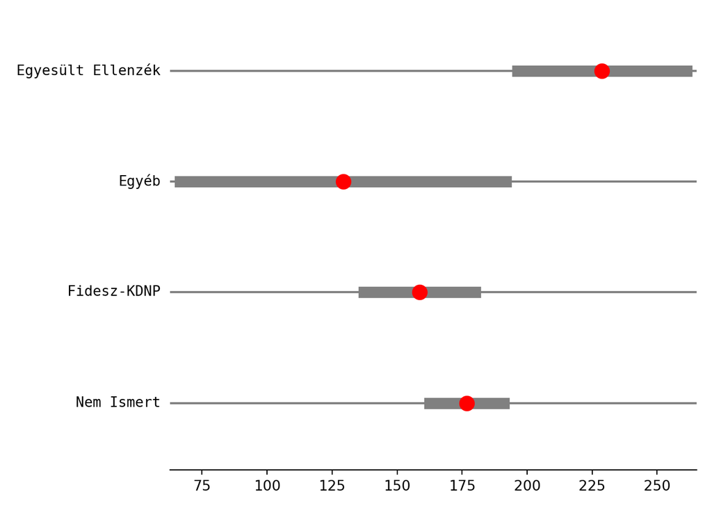

```python
# konfidencia-intervallumok méretének megadása az ábrához
intervallumok = np.abs(PartPrefKimutatas[["ci_low_t", "ci_upp_t"]] - PartPrefKimutatas[["Atlag"]].values)

dot_plot(
  points=PartPrefKimutatas["Atlag"],
  intervals = intervallumok,
  lines=PartPrefKimutatas.index)

plt.tight_layout() # ne csússzanak ki a tengelyfeliratok
plt.show()
```

Láthatóan tágultak a $99\%$-os konfidencia-intervallumok, de az még mindig igaz, hogy az Ellenzék átlagos ideje a sokaságban egyértelműen magasabb, mint a többi párt esetében tapasztalt még konfidencia-intervallumokkal együtt is. Bár a kis elemszámuknak köszönhetően az Egyéb pártra szavazók felső konfidencia-intervallum határa már majdnem beéri őket. :) Ez ugye várható volt, mert $n=13$ esetén azért sokat dob a $k$ megbízhatósági szorzó értékén az $n-1$ szabadságfokú t-eloszlás. :)